# Python

## Що? Як? Навіщо?

Шило Максим

# Пайтон (Python)

— це потужна мова програмування,( запозичено назву з британського шоу Монті Пайтон) розроблена в 1990 році Гвідо ван Россумом, якою легко оволодіти. Вона має ефективні структури даних високого рівня та простий, але ефективний підхід до об'єктно-орієнтованого програмування. Елегантний синтаксис Пайтона, динамічна обробка типів, а також те, що це інтерпретована мова, роблять його ідеальним для написання скриптів та швидкої розробки прикладних програм у багатьох галузях на більшості платформ.

Розробники мови Python є прихильниками певної філософії програмування, яку називають «The Zen of Python» («Дзен Пайтона»):

- Гарне краще, ніж потворне.
- Явне краще, ніж неявне.
- Просте краще, ніж складне.
- Складне краще, ніж заплутане.
- Плоске краще, ніж вкладене.
- Розріджене краще, ніж щільне.
- Легкість читання має значення.
- Особливі випадки не настільки особливі, аби порушувати правила.
- При цьому практичність важливіше бездоганності.
- Помилки ніколи не повинні замовчуватися.

### Гві́до ван Ро́ссум

— нідерландський програміст, відомий завдяки створенню популярної високорівневої мови програмування Python.

[figure not shown]

# Чому саме Python?

[figure not shown]

### - Надійність

[figure not shown]

Цю мову програмування обирають дуже багато компаній. Найбільш відомі це: Google, Tesla, Bank of America, Amazon, Яндекс, Facebook, Netflix, Quora, Reddit та інші не менш відомі корпорації.

### -Використання у веб розробці

[figure not shown]

Веб-джерело є однією з основних ресурсів інформації. Завдяки такому додатку як Django пишеться багато сайтів, такі як YouTube, Google Search, DropBox, Instagram, Reddit, Pinterest, Spotify.

### - Використання у Data Science

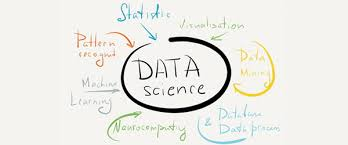

Data Science, Big Data, Predictive Analytics, Machine Learning — популярні тренди у сучасних інформаційних технологіях. Посади спеціалістів з аналізу даних стали одними із найбажаніших в ІТ-секторі. З’явилась велика кількість Data Scientists та популяризаторів цього напрямку, які розказують про фантастичні можливості сучасного аналізу даних, машинного навчання, зокрема, нейронних мереж.

Це основні причини, щоб взагалі розпочати цікавитися програмуванням, оскільки в майбутньому потрібніше знати не як писати ручкою, а як кодити.

[figure not shown]

## Ось рейтинги мови Python від різних ресурсів:

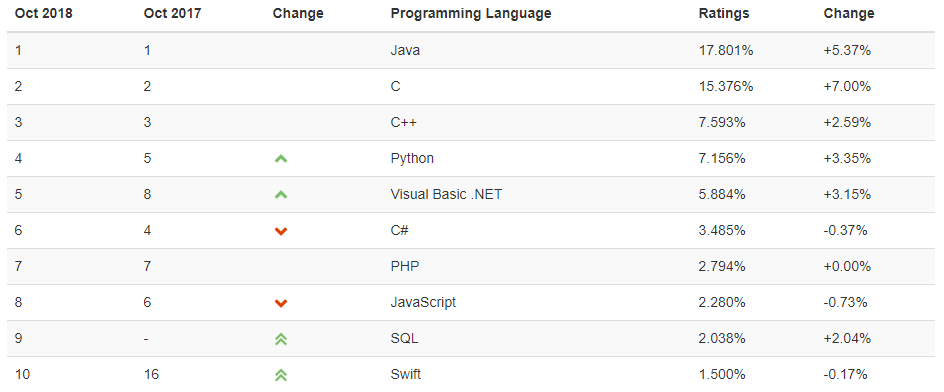

PYPL PopularitY of Programming Language - http://pypl.github.io/PYPL.html

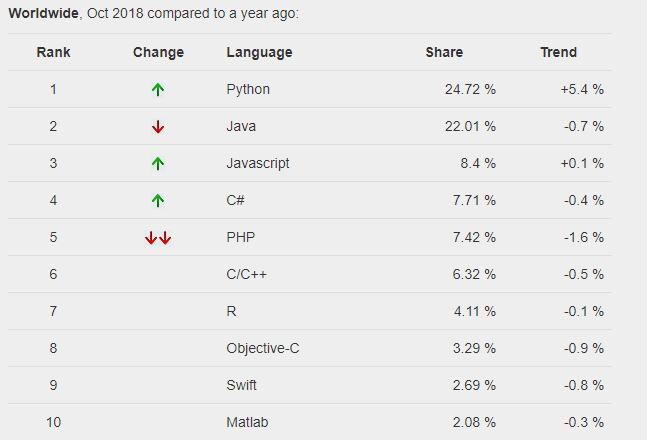

Гoловний ресурс для навчання це: https://www.python.org/

Посилання на завантаження: https://www.python.org/downloads/

На даний час актуальна версія 3.7.0

Якщо у вас Linux, то команнда для терміналу має такий вигляд: 'sudo apt install python'

Але, оскільки для зручності нашої роботи та навчання є спеціальна програма, то пропоную її завантажити та інсталювати.

Вона має назву Anaconda. Ось посилання на завантаження - https://www.anaconda.com/download/

- Потрібно обирати актуальну версію для Пайтона 3.7.
- Під час інсталяції погоджуйтеся на всі умови.

Взагалі потрібності завантажувати окремо Пайтон я не бачу,оскільки він є частиною Anaconda.

# Що ж таке Anaconda?

[figure not shown]

Це дистрибутив для мов програмування Python та R з відкритим кодом для обробки даних великого об'єму, побудови аналітичних прогнозів і наукових обчислень.

Програмне забезпечення, яке ми будемо з вами використовувати це Jupyter Notebook. Його можна запустити ,написавши "jupyter notebook" в cmd(windows) , або terminal(Mac OS, Linux)

- https://metanit.com/python/tutorial/1.1.php - Введение в Python. Язык программирования Python
- http://mit.spbau.ru/files/Python.pdf - Введение в Python
- https://younglinux.info/python.php - Python. Введение в программирование
- https://www.coursera.org/specializations/python - Специализация Python for Everybody (Курс)

І нарешті давайте разом напишемо ПЕРШУ ПРОГРАМУ НА ЦІЙ НЕПЕРЕВЕРШЕНІЙ МОВІ.

# Програма Hello World

```python
print("Hello world")
```

```
Hello world
```

## Вітаю, тепер ви - ПРОГРАМІСТ.

[figure not shown]

тел. +380989304741

e-mail. shilo03975@gmail.com

telegram. @maksym_shylo